# 4740 Project

Chris VanKerkhove, John Bush

5/25/2021

## A Music Assignment Model

In this Markdown, I will document my process of creating and validating different models (with increasing complexity) for classifying music snippets into different musical genres.

The data is taken from Kaggle from the page https://www.kaggle.com/insiyeah/musicfeatures. The data was generated using 30 second MP3 snippets of songs and then extracting features of the sound-bite to act as different predictors.

### Data Preproccessing

Checking for missing values, casting types for classification, ensuring clean data.frame

```r
#Dataset is complete, No missing data
sum(missing)
```

```
## [1] 0
```

```r
#removing file name column ('label' column acts as dependent var)
df <- select(music.dat, -filename)
df$label <- as.factor(df$label)
tibble(df)
```

```
## # A tibble: 1,000 x 29
##    tempo beats chroma_stft   rmse spectral_centro… spectral_bandwi… rolloff
##    <dbl> <dbl>       <dbl>  <dbl>            <dbl>            <dbl>   <dbl>
##  1 103.     50       0.380 0.248             2117.            1957.   4196.
##  2  95.7    44       0.306 0.113             1156.            1498.   2170.
##  3 152.     75       0.253 0.152             1331.            1974.   2900.
##  4 185.     91       0.269 0.119             1361.            1568.   2740.
##  5 161.     74       0.391 0.138             1811.            2052.   3928.
##  6 108.     51       0.357 0.162             2068.            2034.   4231.
##  7 161.     80       0.375 0.110             2340.            2257.   4973.
##  8 152.     74       0.431 0.196             1947.            1980.   3956.
##  9  92.3    45       0.291 0.0892            1110.            1463.   2244.
## 10 152.     70       0.329 0.0670            1172.            1706.   2345.
## # … with 990 more rows, and 22 more variables: zero_crossing_rate <dbl>,
## #   mfcc1 <dbl>, mfcc2 <dbl>, mfcc3 <dbl>, mfcc4 <dbl>, mfcc5 <dbl>,
## #   mfcc6 <dbl>, mfcc7 <dbl>, mfcc8 <dbl>, mfcc9 <dbl>, mfcc10 <dbl>,
## #   mfcc11 <dbl>, mfcc12 <dbl>, mfcc13 <dbl>, mfcc14 <dbl>, mfcc15 <dbl>,
## #   mfcc16 <dbl>, mfcc17 <dbl>, mfcc18 <dbl>, mfcc19 <dbl>, mfcc20 <dbl>,
## #   label <fct>
```

## **Multinomial Classification**

In the following cells I will perform 10-fold CV 10 times, on the KNN algorithm classification for different values of K (number of nearest neighbors to consider during algorithm), and then plot to determine the best value of K.

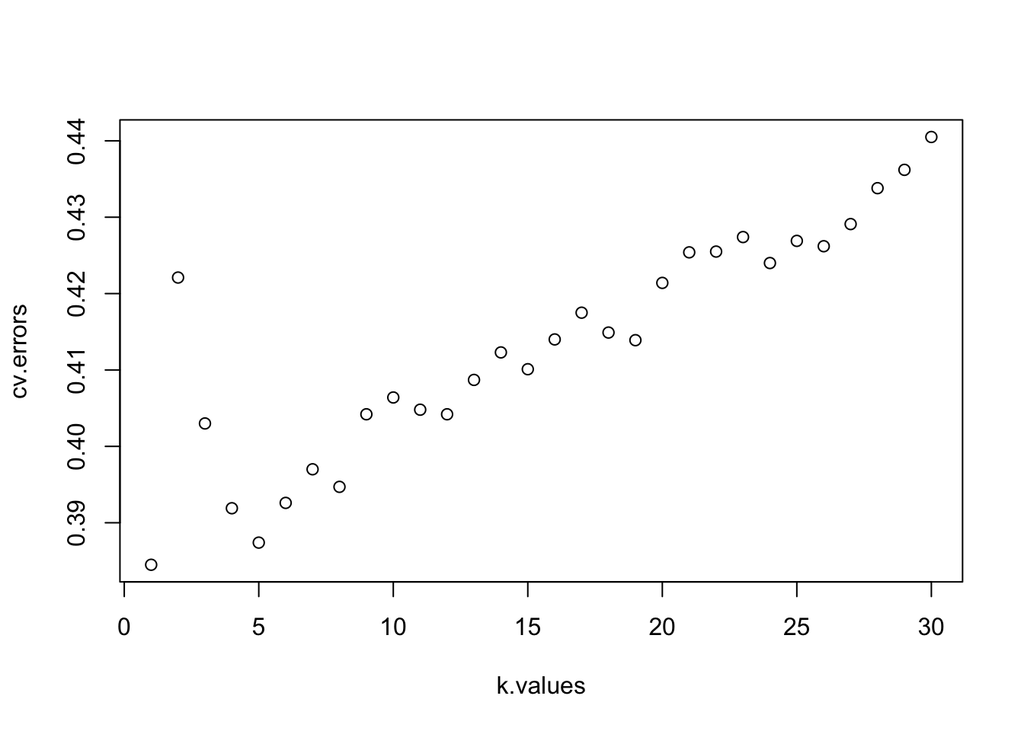

Errors:

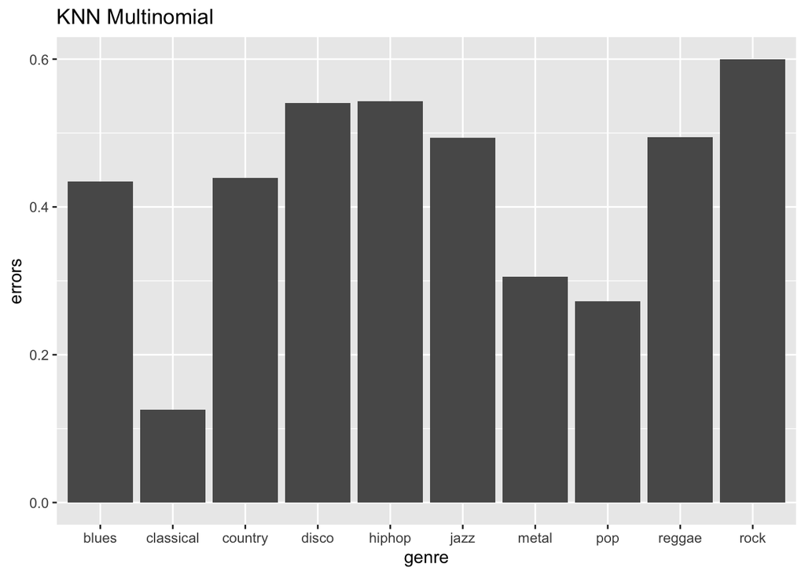

## Decision Trees and Extenstions

In the next section, I will attempt to classify the data using decision tree algorithms, and various extensions such as pruning the tree, bagging, and random forests

### Pruned Decision Tree

In the following cell I use a single decision tree (pruned via 10 fold cv for best k parameter) to perform multinomial classification and plot the classification errors across genres

##### Tree Summary

```
##
## Classification tree:
## snip.tree(tree = tree.music, nodes = 30L)
## Variables actually used in tree construction:
##  [1] "chroma_stft"        "rmse"               "spectral_bandwidth"
##  [4] "mfcc9"              "mfcc4"              "mfcc2"
##  [7] "zero_crossing_rate" "mfcc13"             "mfcc5"
## [10] "mfcc17"             "spectral_centroid"
## Number of terminal nodes:  16
## Residual mean deviance:  2.592 = 1773 / 684
## Misclassification error rate: 0.46 = 322 / 700
```

##### Multinomial Confusion Matrix

```
##
## tree.pred   blues classical country disco hiphop jazz metal pop reggae rock
##   blues         3         2       8     0      0    1     0   1      0    1
##   classical     2        26       0     1      0    1     0   0      0    0
##   country       3         1       3     1      1    0     0   1      3    3
##   disco         0         0       6    15      5    6     0   7      6    4
##   hiphop        2         0       1     0     13    0     6   1      7    0
##   jazz         10         2       5     0      0   12     0   4      1    6
##   metal         4         0       0     3      4    0    24   0      1    3
##   pop           0         0       0     1      3    0     0  16      2    0
##   reggae        5         0       5     1      3    3     1   1      5    2
##   rock          9         0       3     4      1    0     3   0      2   10
```

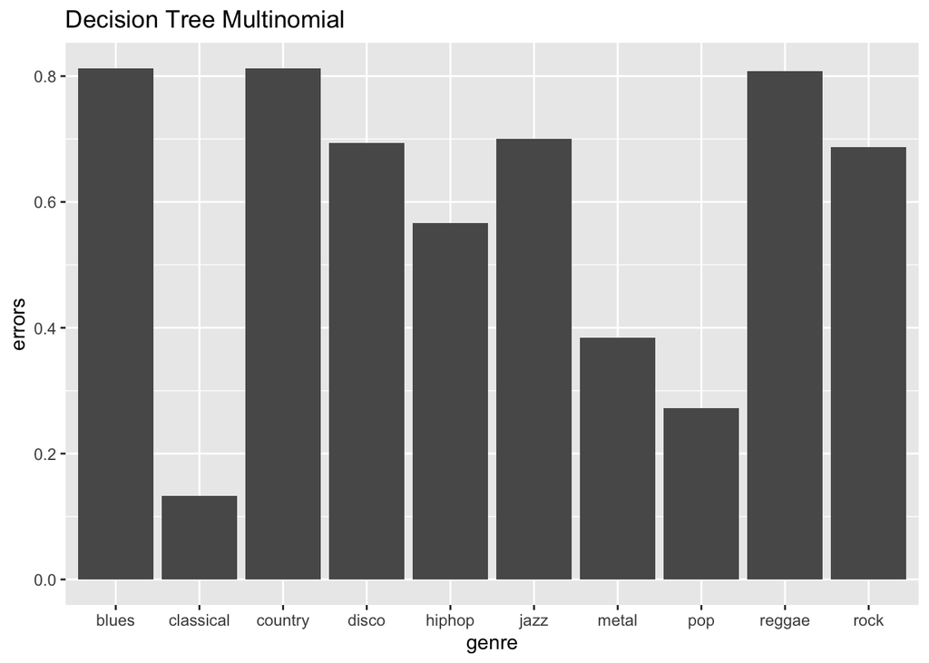

### RandomForest Algorithm

In the next cells I will construct RandomForest models for both multinomial and binary classification. Note the model construction is based of running 10-Fold, 10 iteration Cross Validation. Furthermore the mtry values are selected by running 100 iterations of 10-fold cv and selecting the mtry that most frequently had the lowest cv error. In this case, optimal mtry = 7

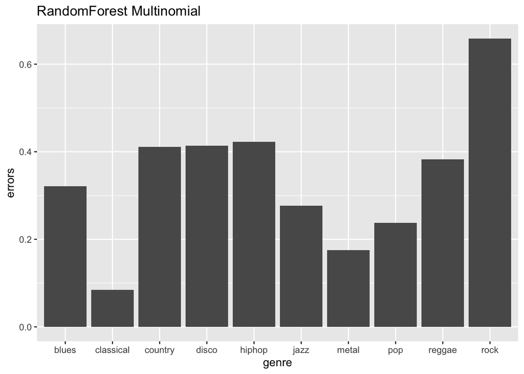

#### Variable Importance

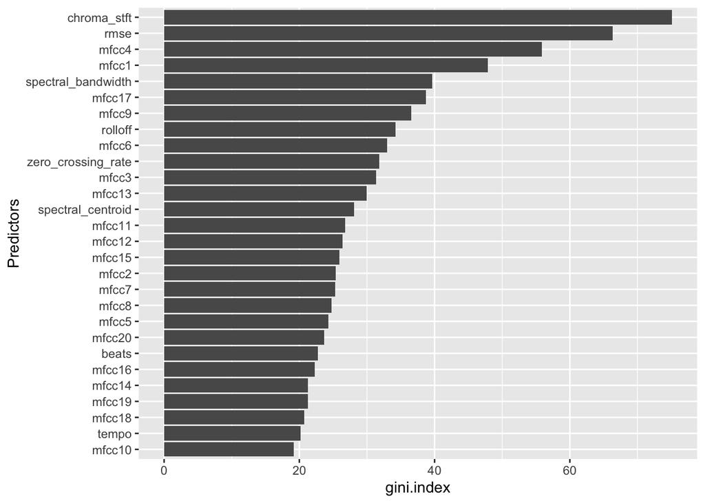

In the next cell, I have selected the top two important variables and plot a few genres to see how the points are clustered in a 2D fashion for visual confirmation purposes

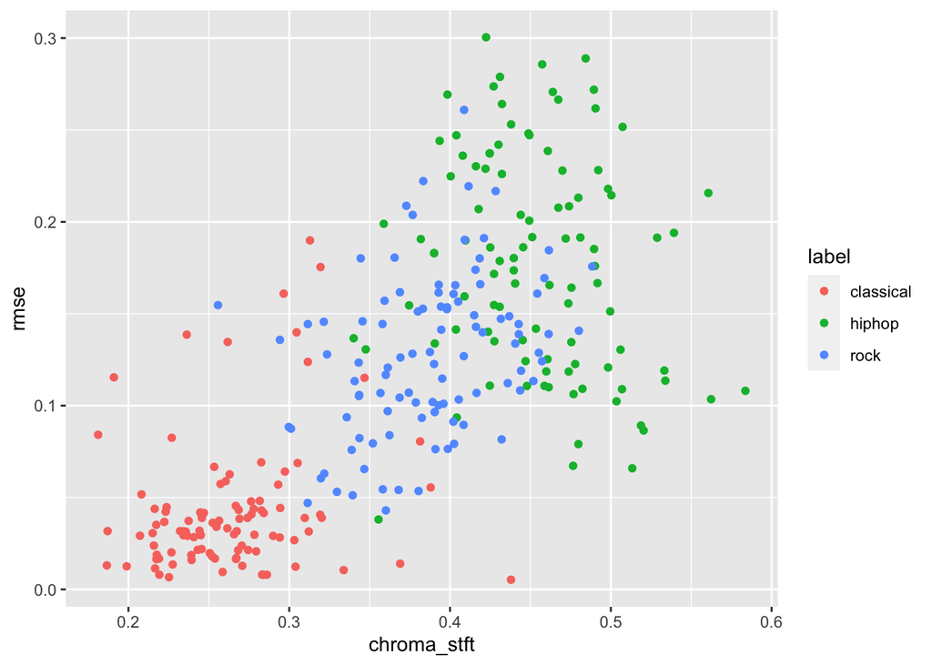

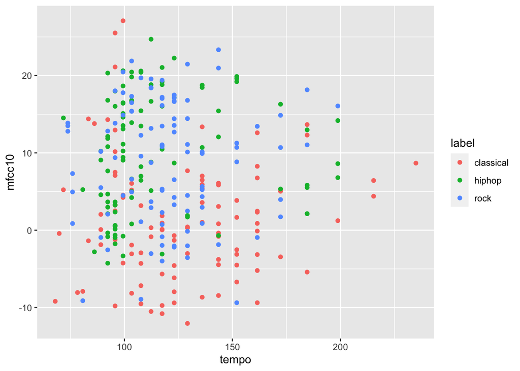

### Multinomial Classification Results

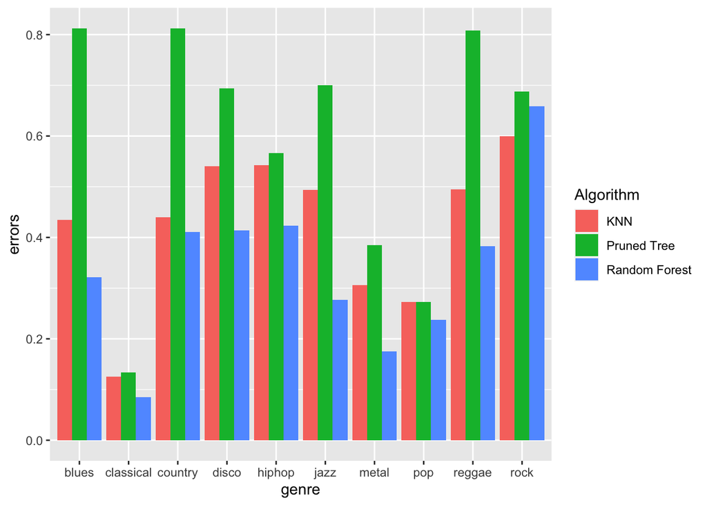

## **Binomial Classification**

## K-Nearest-Neighbor Algorithm

Next, I will use the KNN algorithm, but as a binary classifier, i.e. for each genre I will update the dataframe and change every other genre to “other” so that the column as a factor only has 2 levels (said genre, and other). The goal of this is to improve the accuracy of each genre without multinomial classification. Furthermore, I will use 10 fold CV 10 times f choose a seperate optimal K value for each genre; providing those values of K and plotting the errors.

Another assumption, I randomly select 100 “other” data points to keep the dataset balanced, as we will only have 100 points for each individual genre

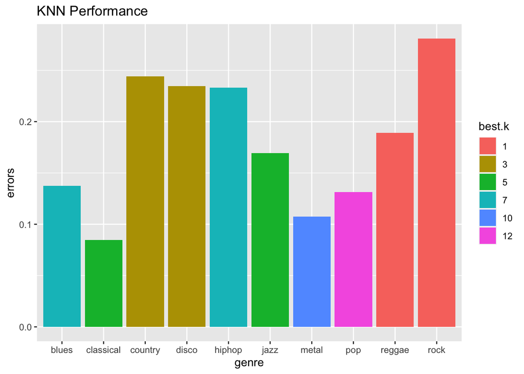

## Pruned Decision Trees

In the next cell I will perform the same process, but only using sub-setted data for binary classification again (200 rows) pruning each tree by their best k parameter using cross-validation

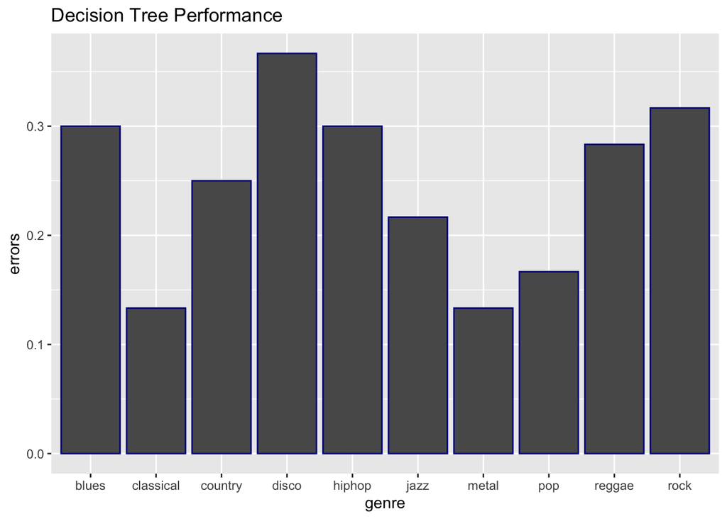

## RandomForest

In this next cell, I will perform Binary classification, in the same ways as above, using the RandomForest algorithm and the optimal tuned mtry (which was found to be 7 using a type of cross validation). The error values depicted in the bar-chart values were found using 10 fold, 10-iteration cross validation.

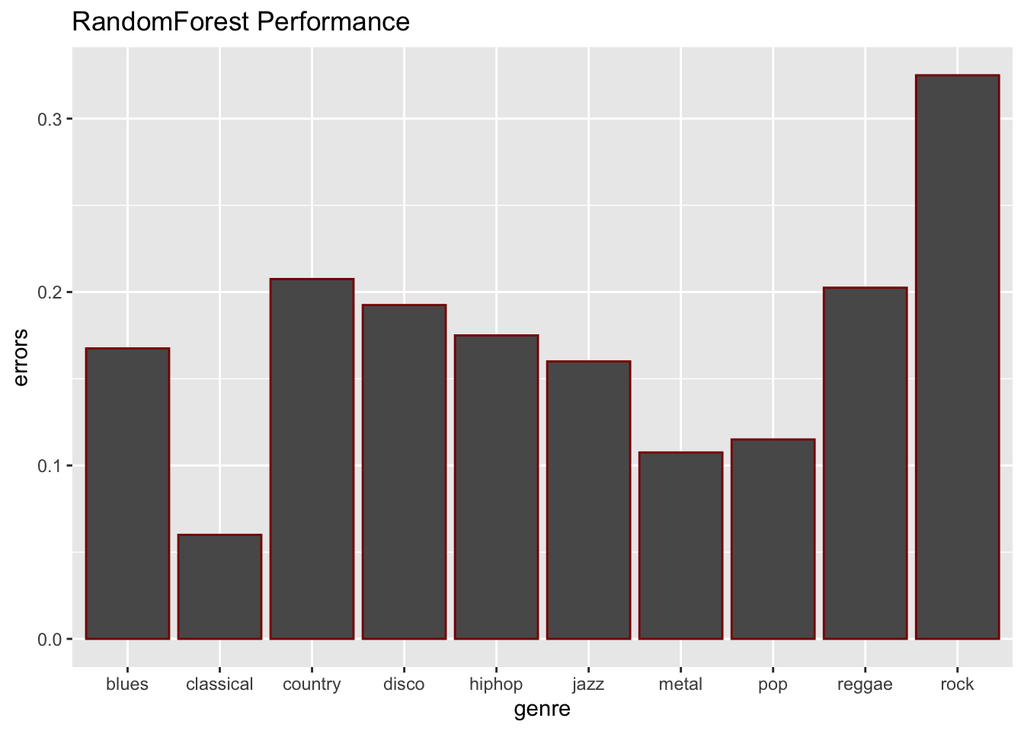

Variable Importance for Rock and Classical Music (Two very different sounding genres)

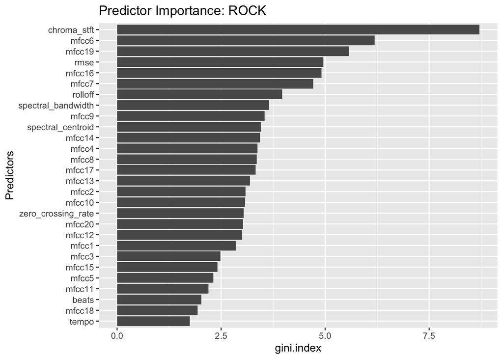

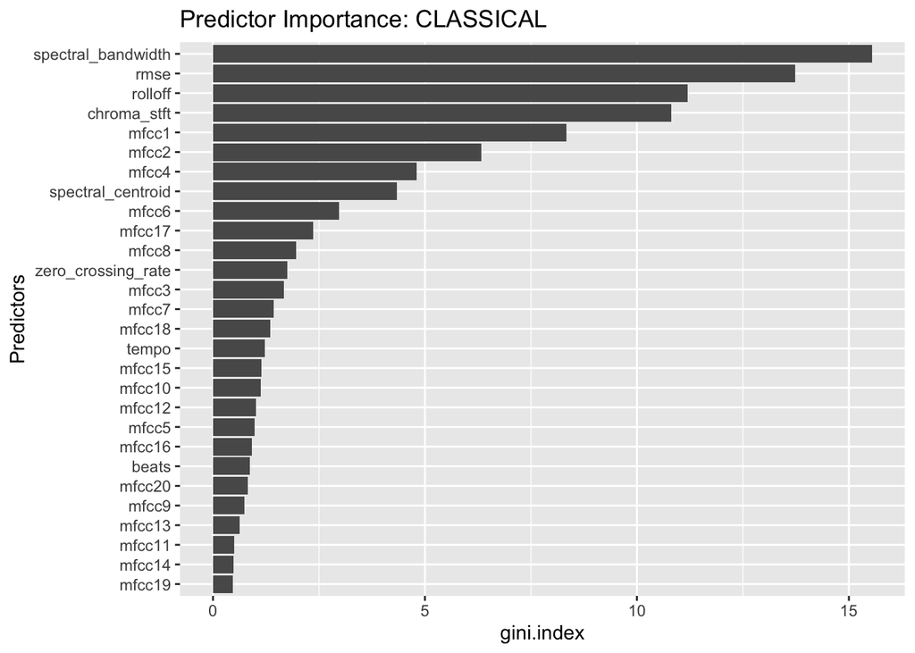

### Results

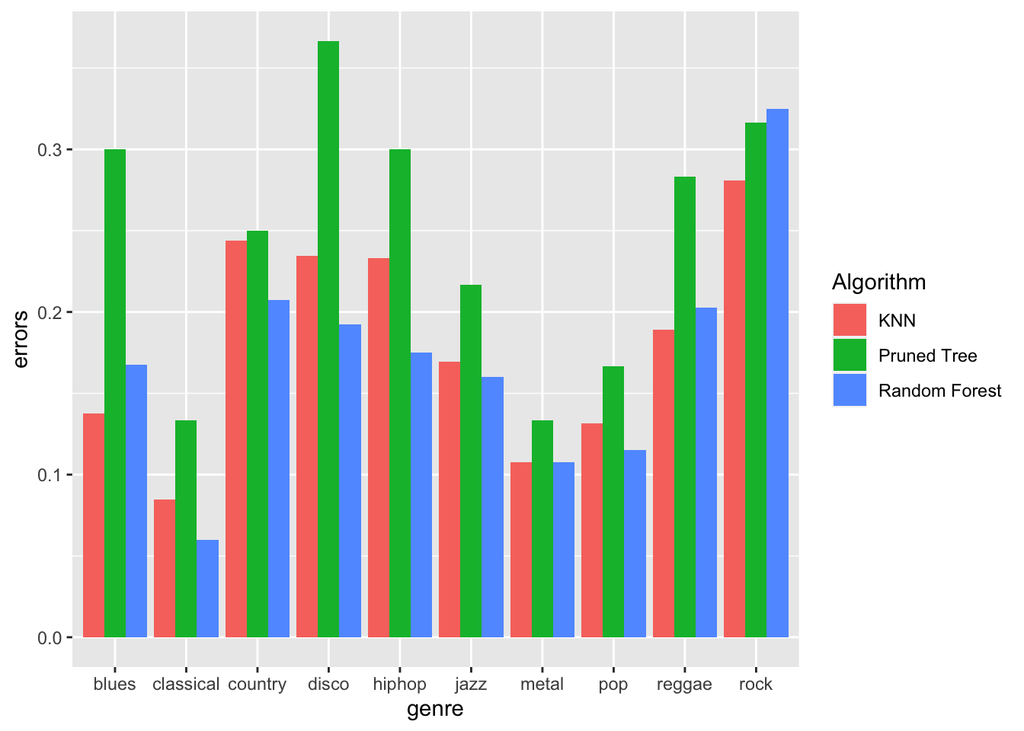